# Python pro studenty Aplikované informatiky

## Operace s řetězci

Nejjednodušší operací nad řetězcem je zjištění jeho délky, tj. počtu znaků v řetězci. Python obsahuje vestavěnou funkci `len` (zkratka za *length*), která vrací délku u všech objektů, u nichž to má smysl (tj. skládají se z nějakého počtu elementárnějších částí)

```python
len("Geralt")
```

```
6
```

```python
len("")  # délka prázdného řetězce
```

```
0
```

Téměř veškeré další manipulace s řetězci lze provádět pomocí tří základních operací: skládání (= spojování) řetězců, indexace (získávání) podřetězců (= souvislých fragmentů řetězů) a hledání podřetězců (i když ne vždy je to nejjednodušší a nejefektivnější).

#### Skládání řetězců

Skládání řetězců se zapisuje pomocí operace `+`.

```python
"Frodo" + "Pytlík"
```

```
'FrodoPytlík'
```

Výsledkem operace je nový objekt: řetězec obsahující všechny znaky levého operandu (řetězce vlevo od operátoru `+`) následované znaky pravého operandu (bez jakéhokoliv oddělení).

Skádání dvou přímo zadaných řetězců není příliš užitečné (spojit dva řetězce není na rozdíl od číslené aritmetiky nevyžaduje kalkulačku v hlavě nebo na papíře). Praktičtější využití nabízí následující miniprogram (zadejte si prosím Vaše skutečná jména).

```python
jmeno = input("Vaše křestní jméno: ")
prijmeni = input("Vaše příjmení: ")

celeJmeno = jmeno + " " + prijmeni # spojení tří řetězců
print(f"Vaše celé jméno je {celeJmeno}")
```

```
Vaše křestní jméno: Jiří
Vaše příjmení: Fišer
Vaše celé jméno je Jiří Fišer
```

#### Indexace

Pro získání podřetězce se v Pythonu používá tzv. **indexace**. Na objekt řetězce se aplikuje index v hranatých závorkách. Nejjednodušším indexem je kladné celé číslo.

```python
s = "Samvěd"
s[1]
```

```
'a'
```

Jak lze vidět tak v tomto případě se vrací podřetězec tvořený jediným znakem a to znak na pozici určené indexem. První znak má pozici 0, druhý pozici 1, atd. V našem případě (index = 1) je tedy vrácen řetězec obsahující znak `a`.

Indexování od nuly může být na první pohled překvapivé a poněkud ztěžuje komunikaci programátorů, neboť lidé preferují počítání od jedné. Třetí znak tak má index 2, a desátý index 9 (obecně n-tý znak má index $n-1$). Je však pro počítače přirozenější a má i další výhody a proto se v programovacích jazycích běžně využívá (jsou však i jazyky, ve kterých zvítězil lidský resp. matematický pohled).

Python je zde však důsledný: **ve všech kontextech (nikoliv jen při počítání znaků) se používají indexy počínající nulou**.

Poslední použitelný index je proto roven délce řetězce bez jedné.

```python
s[5]  # poslední znak šestiznakového řetezce
```

```
'd'
```

Pokud použijeme (omylem) větší index je vyvolána výjimka (a program předčasně končí), Všimněte si, že výjimka informuje o příčině potíží.

```python
s[6]
```

```
---------------------------------------------------------------------------
IndexError                                Traceback (most recent call last)
<ipython-input-60-6e68df1be101> in <module>()
----> 1 s[6]

IndexError: string index out of range
```

Co se však stane, pokud použijeme záporný index (celé číslo může být i záporné).

```python
s[-1]
```

```
'd'
```

Kupodivu, výjimka nevznikla. Python totiž využívá záporné indexy pro indexování od konce (u řetezců od posledního znaku). Poslední znak má index -1 (bez ohledu na délku řetězce), předposlední -2 atd.

```python
s[-6]  # šestý od konce (což je u šestiznakového řetězce první znak)
```

```
'S'
```

#### Výřezy

U získávání jednotlivých znaků však indexace v Pythonu nekončí. Lze získat i delší podřetězce pomocí tzv. výřezů (angl. *slice*).

```python
s[1:3]
```

```
'am'
```

Zápis 1:3 tedy vyjadřuje pozice od indexu 1 (včetně) do indexu 3 (vyjma) tj. dvě pozice (= dva znaky po indexaci). Délka výsledného řetězce je vždy horní_mez - dolní_mez.

```python
s[1:4]  # 3 znaky od druhého (index 0) do pátého (index 4) vyjma (= druhý, třetí, čtvrtý)
```

```
'amv'
```

Výřezem můžeme získat i celý původní řetězec (přesněji jeho kopii, neboť při indexaci vždy vzniká nový objekt)

```python
s[0:6]  # šest znaků (od indexu 0 do indexu 5)
```

```
'Samvěd'
```

To však ještě není vše. Ve výřezech můžete používat i záporné indexy (počítané od konce) a dokonce jednotlivé meze vynechávat. Pokud vynecháte první pak se začíná indexem 0 (první znak) a končí indexem rovným délce seznamu (pozice za posledním znakem).

```python
print (s[0:-1])  # řetězec bez posledního znaku (-1 je index posledníjo znaku, který již do výřezu nepatří)
print (s[2:-2])  # od třetího (včetně) k předpředposlednímu (vyjma) = ke znaku s indexem 6-2 (vyjma) = 4
```

```
Samvě
mv
```

```python
print(s[:2])    # první dva znaky (od indexu nula včetně do dva vyjma)
print(s[:-2])   # bez posledních dvou znaků (od indexu nula včetně do indexu 6-2 vyjma)
```

```
Sa
Samv
```

```python
print(s[3:])   # od indexu 3 (čtvrtý znak) do konce (= bez prvních tří)
print(s[-1:])  # od posledního do konce (= poslední jeden)
```

```
věd
d
```

A nakonec typický Pythonský ideom (zápis, který se v Pythonu relativně často používá, ale nikdo z nezasvěcených mu nerozumí).

```python
print(s[:])  # vrací kopii řetězce
```

```
Samvěd
```

> **Poznámka**: Pokud však rozumíte Pythonu opravdu dobře, pak zjistíte, že tento ideom nemusí na řetězce fungovat, neboť je zbytečné vytvářet kopii neměnných objektů. Kopii od originálu totiž u neměnných objektů nikdy nerozlišíte (pro rozlišení by stačilo jeden z objektů změnit, ale to se u neměnných objektů z principu nelze).

> Představte si, že máte rozlišit mezi dvěma identickými jednovaječnými dvojčaty (bez možnosti je vidět pohromadě). Pokud jsou slepí, hluší a nemůžete se jich dotknout (zanechat např. znaménko) tj. jsou neměnní, pak se vám to nikdy nepodaří.

> Jedinou šancí jak tento trik rozpoznat je testování identity objektů, to však praktickou nerozlišitelnost neovlivní (stejně jako, když uvidíte obě dvojčata zároveň).

```python
s[:] is s  # Python je skutečně inteligentní (kopírováním se neobtěžoval, objekt  s je identický s objektem [:])
```

```
True
```

> **Úkol:** Napiště výraz, který z daného řetězce vytvoří nový, jenž nebude obsahovat předposlední znak (rada: nový řetězec není souvislým podřetězcem původního)

```python
mesto = "Praha"
mesto[:-2] + mesto[-1]
```

```
'Praa'
```

#### Hledání podřetězců

Pro ověření, zda je nějaký (pod)řetězec obsažen v jiném řetězci lze využít operátor `in`:

```python
"alf" in "Gandalf"
```

```
True
```

Vlevo je hledaný (podřetězec), vpravo řetězec v němž hledáme. Výsledkem je pravdivostní hodnota ("alf" je obsažen v řetezci "Gandalf" a proto je výsledkem našeho příkladu hodnota `True`).

*Řešený příklad*

Vytvořte jednoduchý program který zjistí, zda je v zadané genomové sekvenci (tvořený posloupností bází, jež jsou representovány znaky ACGU) obsažen zadaný kodon (trojice znaků tvořená kombinací znaků ACGU).

```python
genom = input("Genom (kombinace znaků ACGU):")
kodon = input("Kodon (trojznaková kombinace znaků ACGU):")

if kodon in genom:
    print(f"Kodon {kodon} je obsažen v genomu {genom}")
else:
    print(f"Kodon {kodon} není obsažen v genomu {genom}")
```

```
Genom (kombinace znaků ACGU):ACGUAACGC
Kodon (trojznaková kombinace znaků ACGU):CGC
Kodon CGC je obsažen v genomu ACGUAACGC
```

Tento program má ještě k dokonalosti daleko. Hlavním problémem je testování správnosti vstupu, neboť do vstupních polí můžete zadat libovolný řetězec (nekontroluje se zda obsahují pouze znagy ACGU).

[dočasné přerušení příkladu]

#### Metody a operace pro testování struktury řetězců

Kontrola, zda řetězec splňuje určitou podmínku ohledně obsahu, není za použití elementárních nástrojů (výřezy, operátor `in`) ve vždy jednoduchá.

Mezi ty jednoduché operace testování patří:

a) řetězec je obsažen v jiném řetězci

```python
"gard" in "Asgard"
```

```
True
```

b) řetězec není obsažen v jiném řetězci (negace bodu a)

```python
"gard" not in "Asgard"
```

```
False
```

Tento zápis s použitím negace operátoru `not in` je přehlednější (a bližší přirozenému *anglickému* jazyku) než zápis s běžnou negací (závorky jsou zde nutné, negace má vyší prioritu než operátor `in`):

```python
not ("gard" in "Asgard")
```

```
False
```

c) řetězec začíná nějakým podřetězcem (prefixem):

```python
"Asgard"[:2] == "As" # výřez vrací první dva znaky (s indexy 0 a 1)
```

```
True
```

Hledání prefixu je tak běžnou operací, že pro ni existuje i přehlednější zápis využívající metody `startswith`. Metoda je v zásadě speciálním případem volání funkce, v němž je nejdříve uveden objekt, který je hlavním parametrem a teprve poté (po tečce) jméno funkce a ostatní parametry (v závorkách).

```python
"Asgard".startswith("As")
```

```
True
```

Řetězec `"Asgard"` je hlavním parametrem metody (tj. objektem, s nímž se snažíme komunikovat), metoda se jmenuje `startswith` a dalším (vedlejším) parametrem je hledaný prefix (počátek řetězce). Výsledkem je i zde logická hodnota.

> *Poznámka*: Metody (včetně zápisu jejich volání) pocházejí ze světa tzv. objektově orientovaného programování. To vychází z představy, že různé objekty spolu interagují tím, že si navzájem volají své metody (které mohou být navíc doplněny dalšími parametry tj. interakce nemusí být typu jeden s jedním). To, který objekt je hlavní parametr (v OOP terminologii adresát) a které jsou dodatečné je dáno pouze zvoleným pohledem. V případě metody `startswith` je adresátem prohledávaný řetězec a dodatečným parametrem podřetězec (hledaný prefix). Lze si však představit i opačný model např. volání typu `"As".isprefixof("Asgard")`, který se však v Pythonu neuplatnil.

d) řetězec končí nějakým podřetězcem (sufixem)

I když i zde můžete použít výřez (a porovnání řetězců), tak i pro testování sufixu existuje specializovaná metoda (jejíž jméno určitě odhadnete)

```python
"Asgard"[-2:] == "rd"
```

```
True
```

```python
"Asgard".endswith("rd")
```

```
True
```

e) všechny znaky řetězce patří do určité třídy znaků

Znaky lze podle jejich funkce klasifikovat do několika kategorií. Mezi hlavní kategorie patří *písmena* (znaky použitelné pro zápis přirozeného jazyka), *číslice* (znaky sloužící pro zápis čísel) a mzerové znaky (bílé tj. netištěné oddělovače). U těchto klíčových kategorií (a pár dalších) lze využít metod, které testují, zda všechny znaky řetězce patří do příslušné skupiny.

```python
print("Dobříň".isalpha())  # všechny znaky jsou písmena
print("42".isdigit()) # všechny znaky jsou číslice
print("  \t \n".isspace())  # všechny znaky jsou mezerové znaky (patří tam i tabulátor a odřádkování)
```

```
True
True
True
```

> **Úkol**: Napište program, který pro daný řetězcový vstup ověří, že jeho první i poslední znak je číslo (ostatní znaky mohou být jakékoliv). Pokud řetězec odpovídá, je vypsán text "Platný vstup" (v opačném případě se nic nevypíše).

```python
vstup = input()
if vstup[0].isdigit() and vstup[-1].isdigit(): # výsledkem indexace je jednoznakový řetězec
    print("Platný vstup")
```

```
1a2
Platný vstup
```

I když jsou tyto metody užitečné, mají několik nevýhod. Za prvé je lze využít jen pro pár všeobecně používaných kategorií znaků (mezi tyto tyto kategorie rozhodně nepatří napříkald znaky genetického kódu). Navíc jsou tyto kategorie výrazně širší než byste čekali. Moderní počítače podporují znaky všech jazyků a písmených soustav (včetně např. emotikonů). Tj. písmena nejsou omezena na latinku a číslice na euroarabské dekadické číslice.

```python
print("Ζεύς".isalpha())  # řecké písmo
```

```
True
```

```python
print("٤٢".isdigit()) # arabsko indické číslice
```

```
True
```

I když je užitečné znát všechny výše uvedené metody a operaci `in` existuje v Pythonu nástroj, který je všechny nejen nahradí, ale vyřeší i jejich nedostatky — regulární výrazy.

#### Regulární výrazy I

Regulární výrazy (název pochází z matematické teorie tzv. gramatik) jsou více než užitečným nástrojem pro práci s řetězci. Používány jsou již od sedmdesátých let, ale jejich současná podoba se vyprofilovala v jazyce *Perl* v letech osmdesátých. Python stejně jako většina ostatních programovacích jazyků a aplikací převzala perlovskou syntaxi (s malými omezeními i rozšířeními, tj. různé implementace regulárních jazyků se v detailech mohou lišit, společný základ je však naštěstí dosti rozsáhlý).

Regulární výrazy jsou velmi komplexním jazykem pro popis struktury řetězců (o regulárních výrazech vycházejí celé knihy). My se omezíme jen na nezbytné základy se kterými se navíc seznámíme jen postupně. Vyhneme se navíc také jejich teorii (i když ta je zajímavá a může výrazně pomoci při tvorbě rozsáhlejších výrazů).

Regulární výraz je v zásadě řetězec, který jednoznačně definuje určitou množinu řetězců s podobnou strukturou. Tato množina může být i jednoprvková, ale typicky je potenciálně nekonečná (tj. s neomezeným opakováním nějakého vzoru).

Základní operací nad regulárními výrazy je test shody (angl. *match*). Tato operace testuje zda zadaný řetězec odpovídá regulárnímu výrazu či nikoliv. V Pythonu je tato operace implementována pomocí metody `fullmatch` modulu `re` (zkratka ze *Regular Expression*). Funkce má dva parametry: nejprve regulární výraz (vzor, jak by měl řetězec vypadat), a poté testovaný řetězec.

```python
import re
s = input()                  # načteme řetězec
if re.fullmatch("[ab]+", s): # otestujeme, zda řetězec odpovídá regulárnímu výrazu
    print("shoda!")          # pokud ano
else:
    print("špatný řetězec")  # pokud ne
```

```
abbababababc
špatný řetězec
```

Znaky v řetězci regulárního výrazu mají dvě zcela odlišné funkce. Písmena, čísla a bílé znaky (mezery) jsou tzv. **terminály**, tj. znaky, které budou (resp. potenciálně mohou být) obsaženy v popisovaném řetězci (tj. v regulárním označují sebe sama). V našem příkladě jsou to znaky `a` a `b` (výsledný řetězec tak může obsahovat jen tyto znaky a žádné jiné). Ostatní znaky mohou mít speciální význam, který závisí na jejich použití: mohou popisovat výběr z z nějaké skupiny znaků, pozice mezi znaky, operátory nad vnořenými regulárními jazyky, apod.

Hranaté závorky použité v regulárním výrazu `[ab]+`, popisují právě jeden znak, kterým může být buď znak `a` nebo znak `b` (nikoliv oba najednou). Na tento regulární (pod)výraz je aplikován operátor `+`, který v případě regulárních výrazů znamená, že tento řetězec popsaný tímto podvýrazem se může libovolněkrát opakovat (ale musí tam být vždy alespoň jednou). V každém opakování se vždy můžeme rozhodnout mezi `a` nebo `b`, tj. regulární výraz popisuje všechny řetězce libovolné délky (avšak neprázdné!), tvořené znaky `a` a `b`, například `a`, `b`, `ab`, `ba`, `aaa`, `aab`, `aba`, … `abba`, `baba`, atd.

Výsledkem aplikace regulárního výrazu je v případě shody vzoru a řetězce tzv. *match* objekt, který nese dodatečné informace o shodě. Vyzkoušejme například následující příklad:

```python
pattern = "a+"
s = "aaa"
re.fullmatch(pattern, s)
```

```
<_sre.SRE_Match object; span=(0, 3), match='aaa'>
```

Regulární výraz popisuje řetězce tvořené jen znaky `a` (znak `a` je terminál, který se může libovolně opakovat). Výsledný *match* objekt nemá standardní textovou representaci (jako např. čísla) a tak je vypsána jeho pomocná textová representace: obsahující třídu objektu a jeho klíčové atributy (pozice shody, apod.). Pomocná textová representace je navíc v tzv. lomených závorkách (znaky menší a větší než).

Pomocná textová representace ve většině případů ukazuje, že se snažíme vypsat příliš složitý objekt. Řešením je vypsání některého z jeho atributů nebo přetypování na jednodušší objekt. V našem případě nás zajímá jen logická hodnota (splňuje/nesplňuje), takže zkusíme tento objekt převést na pravdivostní hodnotu:

```python
bool(re.fullmatch(pattern,s))
```

```
True
```

Toto přetypování se provádí u každé podmínky konstrukce `if` a tak lze na místě podmínky použít i složitější objekty, pokud mají rozumné přetypování na logické hodnoty.

Co se však stane pokud, řetězec vzoru neodpovídá.

```python
re.fullmatch(pattern, "aaaaaaaaac")
```

Zdá se, že v tomto případě metoda nic nevrací. V Pythonu však každá funkce či metoda musí něco vracet. V nejhorším případě vrací hodnotu `None` (to není kontradikce; `None` není nic, jen něco co není dostupné nebo není aplikovatelné). Možná už tušíte co se stane, pokud se pokusíme `None` přetypovat na pravdivostní hodnotu:

```python
bool(None)
```

```
False
```

Ano. 'None' je vždy nepravdivé. Nyní už by mělo být jasné, jak funguje větvení programu v prvním příkladě s regulárními výrazy. Pokud řetězec odpovídá regulárnímu výrazu, pak se jde větví `if` (výsledný *match* objekt je vždy pravdivý), jinak se pokračuje větví `else` (výsledná hodnota `None` je nepravdivá).

> *Poznámka*: Pro ty, co nechtějí využívat *magického* rozdělené světa Pythonských objektů na pravdivé a nepravdivé (proč je, probůh, například úspěch vždy pravdivý) existuje i explicitnější podmínka: `re.fullmatch(pattern,string) is not None`. Python podporuje jak pohodlnost implicitnosti tak jistotu explicitnosti (i když Zen of Python tvrdí: 'Explicit is better than implicit.'

> **Úkol**: Jaké řetězce popisuje regulární výraz `(ab)+`? Vyzkoušejte svoji teorii pomocí několika vhodně zvolených příkladů řetězců (všechny vyzkoušet nemůžete, tento regulární výraz popisuje potenciálně nekonečné množství řetězců).

```python
pattern = "(ab)+"
testString = "aabb" # zde můžete zadat zkušební řetězce
bool(re.fullmatch(pattern, testString))
```

```
False
```

Nyní se můžeme vrátit k řešenému příkladu s genetickým kódem. Pomocí regulárních výrazů je snadné otestovat zda je zadaný řetězec tvořen jen znaky využívanými pro zápis genetického kódu (representují jednotlivé nukleotidy). Nejdříve navrhneme regulární výraz popisující genetický kód libovolné délky tj. řetězec obsahující libovolně dlouhou posloupnost znaků `A`,`C`,`G` a `T`.

```python
import re
re.fullmatch("[ACGT]+", "ACCGGCCTTTC") # otestujte i pro jiné (i nepřípustné) řetězce
```

```
<_sre.SRE_Match object; span=(0, 11), match='ACCGGCCTTTC'>
```

Jen o málo složitější je regulární výraz pro trojpísmenné kodony:

```python
re.fullmatch("[ACGT][ACGT][ACGT]", "AAA")
```

```
<_sre.SRE_Match object; span=(0, 3), match='AAA'>
```

Všimněte si, že každá znaková množina popisuje právě jeden znak tj. daným regulárním výrazem jsou popsány jen tříznakové řetězce. Každý znak je navíc z omezené (a velmi malé množiny). Lze tedy snadno spočítat, že existuje právě $4^3$ = 64, které jsou tímto regulárním výrazem definovány.

> **Úkol**: Doplňte program pro nalezení kodonu v genomové sekvenci o testování přípustnosti vstupů pomocí výše uvedených regulárních výrazů. V případě, že vstup nevyhovuje vyvolejte výjimku pomocí příkazu `raise Exception("popis výjimečné situace")`. Nezapomeňte podmínku negovat (problém je když řetězec neodpovídá vzoru!).

```python
import re

genom = input("Genom (kombinace znaků ACGU):")
if not re.fullmatch("[ACGT]+", genom):    # ověříme přípustnost zápisu genomu (ještě pře zadáním kodonu)
    raise Exception("Neplatný genom")

kodon = input("Kodon (trojznaková kombinace znaků ACGU):")
if not re.fullmatch("[ACGT][ACGT][ACGT]", kodon):  # a poté ověříme i přípustnost zápisu kodonu
    raise Exception("Neplatný kodon")

if kodon in genom:
    print(f"Kodon {kodon} je obsažen v genomu {genom}")
else:
    print(f"Kodon {kodon} není obsažen v genomu {genom}")
```

```
Genom (kombinace znaků ACGU):AACCCCCGGGGGCCCGGXGGGG
```

```
---------------------------------------------------------------------------
Exception                                 Traceback (most recent call last)
<ipython-input-37-4d795f5d0e29> in <module>()
      3 genom = input("Genom (kombinace znaků ACGU):")
      4 if not re.fullmatch("[ACGT]+", genom):    # ověříme přípustnost zápisu genomu (ještě pře zadáním kodonu)
----> 5     raise Exception("Neplatný genom")
      6
      7 kodon = input("Kodon (trojznaková kombinace znaků ACGU):")

Exception: Neplatný genom
```

Miniúvod do regulárních výrazů ukončíme popisem asi nejužitečnějšího zástupného symbolu. Znak `.` (tečka) má v regulárním výrazu speciální význam — nahrazuje libovolný znak (avšak vždy jen jeden). Ukažme si několik příkladů:

```python
print( re.fullmatch("...", "abc") )  # tři jakékoliv znaky

print( re.fullmatch("a.+", "ahoj" ))   # řetězec začínající a mající alespoň dva znaky
# ("a" + 1 až nekonečně mnoho dalších jednotlivých znaků)

print( re.fullmatch("(.a)+", "ratata")) # řetězec s sudým počtem znaků, kde na každé druhé pozici je 'a'
```

```
<_sre.SRE_Match object; span=(0, 3), match='abc'>
<_sre.SRE_Match object; span=(0, 4), match='ahoj'>
<_sre.SRE_Match object; span=(0, 6), match='ratata'>
```

Pokud chceme v regulárním výrazu využít tečku jako terminální znak (tj. tečku, která stojí sama za sebe), je nutno použít zápis `\\.` (zpětné lomítko je zdvojeno proto, že jej lze v pythonském řetězci zapsat jen pomocí tzv. escape sekvence). Podobně lze jako terminály vkládat i další speciální znaky např. `(` nebo `)`.

```python
re.fullmatch("\\(\\..\\.\\)", "(.a.)")
```

```
<_sre.SRE_Match object; span=(0, 5), match='(.a.)'>
```

Tento regulární výraz obsahuje terminály pro vnější dvojici párových závorek, uvnitř nichž je libovolný znak mezi dvojicí teček (první a třetí tečka je předcházena dvěma lomítky, zatímco druhá nikoliv). Všimněte si, že regulární výraz s větším počtem dvojic zpětných lomítek není příliš přehledný. Mírné zpřehlednění může přinést použití tzv. surových řetězců, v nichž nemá lomítko speciální význam (takže se nemusí zdvojovat). Surové řetězce se zapisují pomocí znaku `r` (angl. *raw*) bezprostředně před uvozovkou resp. apostrofem.

```python
re.fullmatch(r"\(\..\.\)", "(.!.)") # surový řetězec využitý pro zápis regulárních výrazů
```

```
<_sre.SRE_Match object; span=(0, 5), match='(.!.)'>
```

> **Úkol**: Napište program, který pro daný řetězcový vstup ověří, že je tvořen číslem s povinnou desetinou tečkou a desetinnou části.

```python
vstup = input()
if re.fullmatch("[0123456789]+\\.[0123456789]",vstup): # bez použití surového řetězce
    print("Desetinné číslo")
```

```
2.6
Desetinné číslo
```

#### Metody vracející modifikované verze řetězců

V některých situacích se hodí modifikovat některé znaky řetězce (nahradit je jinými, odstranit, či vložit jiné). To však zcela přirozeně nejde, neboť řetězce jsou neměnné objekty.

Náhradním řešením je nahradit (nepřípustnou) modifikaci vytvořením nového řetězce, u něhož jsou dané modifikace provedeny (tj. vytvoří se už v modifikované podobě). Python tento přístup využívá hned u několika metod objektů třídy `string`.

```python
s = "Mis nenasitných sislů"
s.replace("i", "y")   # řetězec označený proměnnou `s` je nezměnen
# nově vytvořený není po provedení řádku dostupný (zaniká)
print(s)  # vypíše se nezměněný původní řetězec

s = s.replace("i", "y") # nový řetězec je přesměrována proměnná 's', původní objekt zaniká
print(s)
```

```
Mis nenasitných sislů
Mys nenasytných syslů
```

Jak lze vidět na příkladě metody `replace`, výsledek je nutno přiřadit do proměnné (jinak volání nemá žádný efekt). Často to bývá proměnná, která označovala původné řetězec (ten se sice stane nedostupným, avšak to v mnoha případech nevadí).

Volání metody `replace` ukazuje základní rys (objektové) programování — spolupráce několika objektů, jejímž výsledkem je nový objekt. Metoda je volána nad objektem (třídy řetězec) a předány jsou jí další dva (dočasně vytvořené) objekty: prvním je nahrazovaný (pod)řetězec, druhým nahrazující. Výsledkem je vytvoření nového řetězce, v němž jsou všechny výskyty prvního podřetězce nahrazeny druhým podřetězcem.

Podívejme se na obrázek.

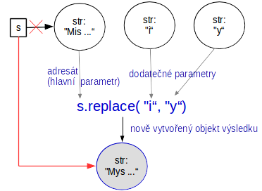

V první fázi (černá barva) jsou postupně vytvořeny vstupní objekty a jeden z nich (původní řetezec) je opatřen proměnnou `s`. Ve druhé fázi (modré) se vykoná volání metody, jehož výsledkem je nový objekt se zaměněnými znaky. Třetí (červená) fáze je přiřazení: odkaz v proměnné je přesměrován na nový objekt (štítek je odlepen z původného objektu a přilepen na nový). Po skončení je dostupný pouze jediný objekt (změněný řetězec). Ostatní objekty už vlastně neexistují.

Zaměňovat lze samozřejmě i delší podřetězce:

```python
s = "Frodo & Sam"
s = s.replace("Frodo", "Bilbo")
print(s)
```

```
Bilbo & Sam
```

Pokud máte ještě složitější požadavky, lze využít funkci `re.sub`, která umožňuje definovat nahrazované řetězce pomocí regulárního výrazu. Jako příklad uveďme nahrazení všech celých čísel v řetězci otazníkem (celé číslo je nahrazeno jediným otazníkem).

```python
s = "333 stříbrných stříkaček stříkalo přes 333 stříbrných střech"
s = re.sub("[0123456789]+", "?", s) # i zde se původní řetězec nemění
print(s)
```

```
? stříbrných stříkaček stříkalo přes ? stříbrných střech
```

Všimněte si, že funkce `re.sub` (není to metoda, `re` není objekt, na nějž je volána, ale modul) má tři parametry v pořadí regulární výraz určující nahrazovanou část (zde libovolná posloupnost číslic), nahrazující řetězec (znak otazníku) a teprve třetím je řetězec, v němž se náhrady provedou (`sub` je zkrácené anglické `substitute`).

> **Úkol**: Vytvořte program, který přečte řetězec a nahradí vícenásobné mezery (tj. mezery tvořené dvěma a více znaky mezer) za mezery jednoduché. To je užitečné, neboť v vložení více mezer za sebou je typickou chybou při zadávání textů. Opravený text následně vypište.

```python
vstup = input()
vstup = re.sub("  +", " ", vstup)  # regulární výraz obsahuje dvě mezery za sebou (druhá se může opakovat)
print(vstup)
```

```
Jiří    Fišer
Jiří Fišer
```

S úpravou víceznakových mezer souvisí i další požadavek. Při zadávání formalizovaných řetězců je nutno preventivně odstraňovat mezery na počátku řetězce a především mezery na jeho konci (ty jsou ve většině případů zcela neviditelné, přesto však mohou negativně ovlivňovat porovnání (i když se řetězce na první pohled neliší, strojově se jedná o dva odlišné řetězce, které se liší už v počtu znaků).

Požadavek na odstranění počátečních a koncových mezer se vyskytuje tak často, že pro něj existuje speciální metida (resp. hned několik speciálních metod).

```python
jmeno = "  Jiří    Fišer   "   # řetězec s nadbytečnými mezerami (na začátku, uprostřed i na  konci)
print( jmeno.lstrip()) # vrací nový řetězec s odstraněnými mezerami na začátku (vlevo = left)
print( jmeno.rstrip()) # vrací nový řetězec s odstraněnými mezerami na konci (vpravo = right)
print( jmeno.strip())  # vrací nových řetezec bez počátečnách i koncových mezer
```

```
Jiří    Fišer
  Jiří    Fišer
Jiří    Fišer
```

Všiměnte si, že odstranění mezer na konci se vizuálně nijak neprojevilo. Navíc se neodstranili vícenásobné mezery uvnitř (resp. přesněji nenahradily za jednoduchou mezeru). Pro tento účel je nutno spojit metodu `strip` se substitucí pomocí regulárního výrazu:

```python
re.sub("  +", " ", jmeno.strip())
```

```
'Jiří Fišer'
```

Nejdříve se odstraní mezery na počátku a na konci (`strip`) a pak se nahradí vícenásobné mezery za jednoduché. Lze to udělat i obráceně:

```python
re.sub("  +", " ", jmeno).strip()
```

```
'Jiří Fišer'
```

Toto řešení může být o něco méně efektivní, neboť zjednodušujeme i ty vícenádobné mezery, které nakonec stejně odstraníme metodou `strip` (což je pravděpodobně o něco rychlejší než substituce). Tuto teorii v Jupyteru snadno ověříme.

```python
%timeit re.sub("  +", " ", jmeno.strip())
```

```
1.47 µs ± 3.38 ns per loop (mean ± std. dev. of 7 runs, 1000000 loops each)
```

```python
%timeit re.sub("  +", " ", jmeno).strip()
```

```
1.79 µs ± 29.1 ns per loop (mean ± std. dev. of 7 runs, 100000 loops each)
```

Rozdíl opravdu existuje, není však příliš velký. První postup je cca 20% rychlejší.

Poslední užitečnou dvojicí jsou funkce, které nahrazují velká písmena (verzálky) za malá (minusky) a vice versa (samozřejmě opět vytvořením nového řetězce).

```python
s = "Minas tirith"

print(s.lower())  # velká na malá (ostatní beze změny)
print(s.upper())  # malá na velká (ostatní beze změny)

print(s.title())  # malá na velká na začátku slov
```

```
minas tirith
MINAS TIRITH
Minas Tirith
```

Tyto funkce se opět hodí při porovnání, V tomto případě tehdy, pokud se nemá brát zřetel na velikost písmen.

```python
s = input("Město: ")
if s.lower() == "ústí nad labem":  # porovnáváme v malých písmenech bez ohledu na vstup
    print("Sídlo UJEP")
```

```
Město: ústí Nad labem
Sídlo UJEP
```